# Simple linear regression

Analyzing the price of a car

## Introduction

This group assignment will use the Cars93 dataset from the MASS package and is inspired from the Lab 8 written by CMU’s Professor Alexandra Chouldechova for her Programming in R for Analytics course.

Packages to be used:

1. `MASS`
2. `tidyverse`
3. `broom`

```r
library(MASS)
library(tidyverse)
library(broom)
library(dplyr)
```

## Data

The Cars93 dataset consists of data from 93 cars on sale in the USA in 1993. It has 27 variables.

```r
attach(MASS::Cars93)
Cars93 <- as_tibble(MASS::Cars93)
glimpse(Cars93)
```

```
Rows: 93
Columns: 27
$ Manufacturer       <fct> Acura, Acura, Audi, Audi, BMW, Buick, Buick, Buick…
$ Model              <fct> Integra, Legend, 90, 100, 535i, Century, LeSabre, …
$ Type               <fct> Small, Midsize, Compact, Midsize, Midsize, Midsize…
$ Min.Price          <dbl> 12.9, 29.2, 25.9, 30.8, 23.7, 14.2, 19.9, 22.6, 26…
$ Price              <dbl> 15.9, 33.9, 29.1, 37.7, 30.0, 15.7, 20.8, 23.7, 26…
$ Max.Price          <dbl> 18.8, 38.7, 32.3, 44.6, 36.2, 17.3, 21.7, 24.9, 26…
$ MPG.city           <int> 25, 18, 20, 19, 22, 22, 19, 16, 19, 16, 16, 25, 25…
$ MPG.highway        <int> 31, 25, 26, 26, 30, 31, 28, 25, 27, 25, 25, 36, 34…
$ AirBags            <fct> None, Driver & Passenger, Driver only, Driver & Pa…
$ DriveTrain         <fct> Front, Front, Front, Front, Rear, Front, Front, Re…
$ Cylinders          <fct> 4, 6, 6, 6, 4, 4, 6, 6, 6, 8, 8, 4, 4, 6, 4, 6, 6,…
$ EngineSize         <dbl> 1.8, 3.2, 2.8, 2.8, 3.5, 2.2, 3.8, 5.7, 3.8, 4.9, …
$ Horsepower         <int> 140, 200, 172, 172, 208, 110, 170, 180, 170, 200, …
$ RPM                <int> 6300, 5500, 5500, 5500, 5700, 5200, 4800, 4000, 48…
$ Rev.per.mile       <int> 2890, 2335, 2280, 2535, 2545, 2565, 1570, 1320, 16…
$ Man.trans.avail    <fct> Yes, Yes, Yes, Yes, Yes, No, No, No, No, No, No, Y…
$ Fuel.tank.capacity <dbl> 13.2, 18.0, 16.9, 21.1, 21.1, 16.4, 18.0, 23.0, 18…
$ Passengers         <int> 5, 5, 5, 6, 4, 6, 6, 6, 5, 6, 5, 5, 5, 4, 6, 7, 8,…
$ Length             <int> 177, 195, 180, 193, 186, 189, 200, 216, 198, 206, …
$ Wheelbase          <int> 102, 115, 102, 106, 109, 105, 111, 116, 108, 114, …
$ Width              <int> 68, 71, 67, 70, 69, 69, 74, 78, 73, 73, 74, 66, 68…
$ Turn.circle        <int> 37, 38, 37, 37, 39, 41, 42, 45, 41, 43, 44, 38, 39…
$ Rear.seat.room     <dbl> 26.5, 30.0, 28.0, 31.0, 27.0, 28.0, 30.5, 30.5, 26…
$ Luggage.room       <int> 11, 15, 14, 17, 13, 16, 17, 21, 14, 18, 14, 13, 14…
$ Weight             <int> 2705, 3560, 3375, 3405, 3640, 2880, 3470, 4105, 34…
$ Origin             <fct> non-USA, non-USA, non-USA, non-USA, non-USA, USA, …
$ Make               <fct> Acura Integra, Acura Legend, Audi 90, Audi 100, BM…
```

```r
levels(AirBags)
```

```
[1] "Driver & Passenger" "Driver only"        "None"
```

#### The variables

[output not shown]

## Exploratory data analysis

#### Question 1

Create a scatter plot between `Price` and the `EngineSize`. Comment on the relationship. What do you think the correlation is between the variables?

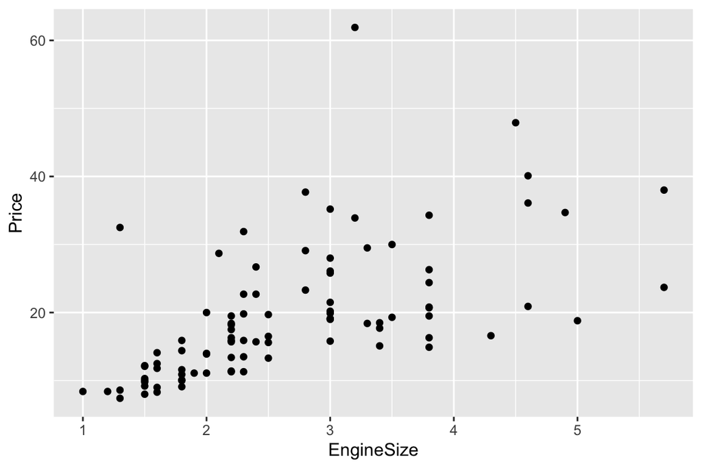

#### Question 2

Create scatter plots between `Price` and categorical variables `Airbags` and `Origin`. Comment on the relationship. Add `geom_jitter()` to your plot. What do you notice about the variability in `Price` between different levels?

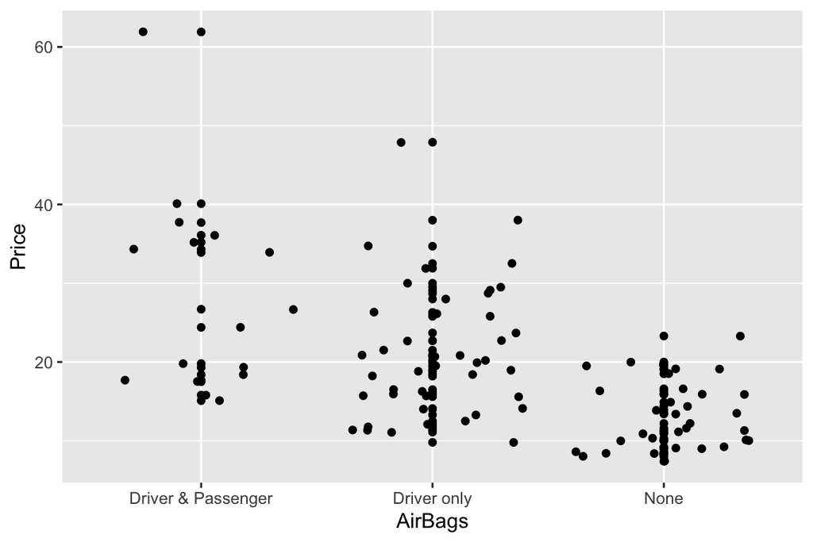

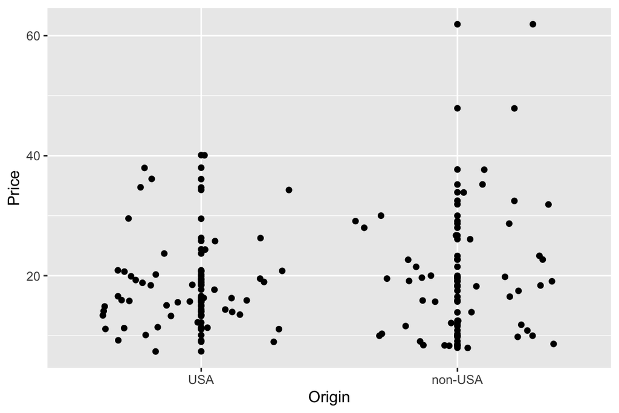